# Ethnic Diversity and Political Rights

13 May 2016

According to the theory, internal embeddedness refers to the qualities of these as simultaneously independent from each other (independence) and support each other (interdependence).

External embeddedness, on the other hand, refers to the embeddedness of this webbed structure in spheres of enabling conditions that protect it from inner and outer destabilizers and shocks, such as a developed economy, fair distribution of resources, and prevention of extreme poverty, to name a few conditions. By his same definition, any democracy where the mutual embeddedness of the five partial regimes is no longer intact is labelled a “defective democracy” (2004).

Our second main source of inspiration was Paul Collier’s studies on the effect of ethnic fractionalization, or the probability that any two individuals drawn from a given population will belong to different ethnic groups, on conflict, and how that effect differs between regime types. He shows that that, while higher ethnic fractionalization can actually play a stabilizing role in developed democracies, it can be quite harmful in authoritarian regimes, depending on the pattern of fractionalization that is present (2000).

This got us to thinking: what sort of role might ethnic diversity, or fractionalization, play on each of Merkel’s five partial regimes that qualify developed democracies? We decided to focus on its effect on political rights, which Merkel defines by two different qualifiers: freedom of speech and opinion, and the freedom of association, demonstration, and petition. He justifies their allotted role as a partial democratic regime by pointing out the important roles they play as an enabler to fair and organized democratic elections and in ensuring the complete development of political society, which in turn behaves as a check and balance on state institutions.

However, we did not think that this was all there was to the equation and so, based on the belief that the level of development of a country would likely play a significant role in explaining the impact of ethnic fractionalization on political rights and recent scholarly research suggesting that excessive inequalities undermine democratic political regimes (2006) and research showing that inequality perpetuated by ethnic divisions is particularly bad for economic growth relative to those perpetuated by other variables and that ethnic fractionalization is an important determinant of institutional quality (2010), we thought that ethnic fractionalization might play an important role in determining the level of Merkel’s political rights when the country is at an advanced stage of development, which we define as the broad distribution of wealth in a country (low economic inequality).

We hypothesized that high ethnic fractionalization would have a negative impact on the preservation of political rights, as different groups compete to dominate the political discourse. We also thought that its impact might depend on the level of income inequality in a country: the less equal a country, the higher the negative impact high ethnic fractionalization will have on political rights. Conversely, the more equal a country, the higher the positive impact high ethnic fractionalization will have on political rights. Our main hypotheses were, then:

**H1: The more ethnically fractionalized a country is, the higher its negative impact on political rights if income inequality is high.**

**H2: When income inequality is low, the impact of high ethnic fractionalization on political rights is expected to be positive.**

We also included the variables of linguistic fractionalization, income (as measured by GDP per capita), and judicial independence as controls.

All the variables used in this study are easily accessed in the Quality of Government Standard Dataset developed by the Quality of Government Institute from Gothenburg (Government Institute 2015), the World Bank’s World Governance Indicators dataset, and the World Development Indicators dataset, which is provided as an R package, also by the World Bank. For more information, please se our Github repository directly: https://github.com/imiller88/IsabelleandDiegosFinalResearchProject.

# Methodology

Due to the lack of availability of data spanning multiple years by our main independent variables, ethnic fractionalization and the Gini coefficient, we were only able to run simple linear models. Therefore, our primary model consists of pooled OLS regressions for the years 2008 and 2010, for which we were able to collect the most complete data.

Our basic equation (from the pooled OLS model) was as follows:

*PoliticalRightsi= B0 + B1EthnicFraci + B2IncomeIneqi + B3EthnicFracxIncomeIneqi + B4GDPcapitai + B5Judiciaryindependencei + B6Voiceandaccounti +B7Linguisticfraci + Errori*

## *A side note on limitations*

Additionally, this study is not able to show any possible changes over time. In order to be able to draw firmer conclusions, it would be ideal to run a panel data model over the course of at least 20-100 years to allow for changes in ethnic fractionalization and inequality to take place due to migration, economic cycles, regime changes, and/or various other mitigating factors.

# Data Exploration

In an attempt to identify any significant patterns, we first look at the distributions of our main variable of interest. Please note the skewness of available Gini Coefficients and the slight skewness of ethnic fractionalization.

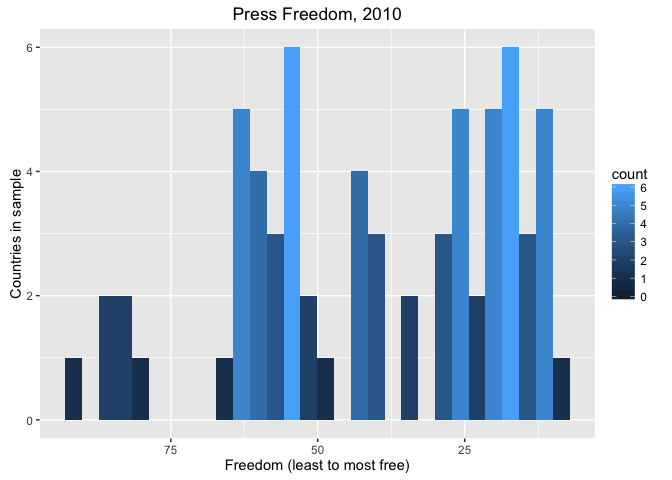

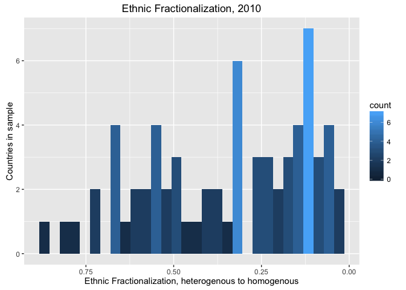

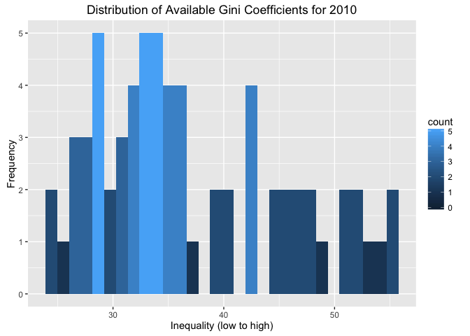

Here we can also see that there seems to be a general negative correlation between both variables (the higher the fractionalization, the lower the press freedom, in accordance with our theory) but there is also a clear dip around an ethnic fractionalization value of 0.30 (a 0.30 chance that any two individuals selected from a given society will belong to different ethnic groups).

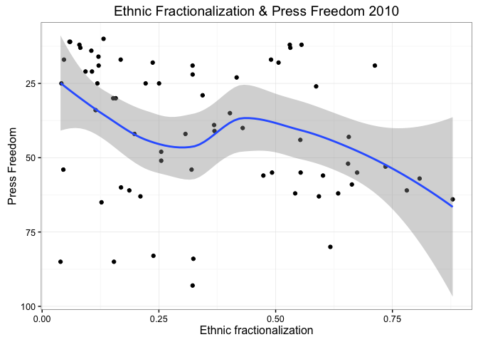

# OLS regression

**Regression Results: Year 2008 (1) and Year 2010 (2)**

[output not shown]

# Conclusion and Grounds for Further Analysis

As previously mentioned, in order to truly be able to draw conclusive relationships between the variables at hand, a larger dataset spanning a much greater time period would be needed. Unfortunately, data on ethnic fractionalization going back large periods of time is difficult to come by, and we were not able to include it in this study. Moreover, there are many countries for which Gini data are not available, hence, limiting our sample.

\newpage

## Bibliography

Acemoglu, Daron, and James Robinson. 2006. *Economic Origins of Democracy and Dictatorship*. New York: Cambridge University Press.

Casey, Gregory P., and Ann L. Owen. 2010. “Inequality and Fractionalization.” Hamilton College.

Collier, Paul. 2000. “Embedded and Defective Democracies.” The World Bank.

Government Institute, Quality of. 2015. “QoG Standard Data.” http://qog.pol.gu.se/data/datadownloads/qogstandarddata.

Merkel, Wolfgang. 2004. “Embedded and Defective Democracies.” *Democratization* 11 (5): 33–58.